# PG1- Oral

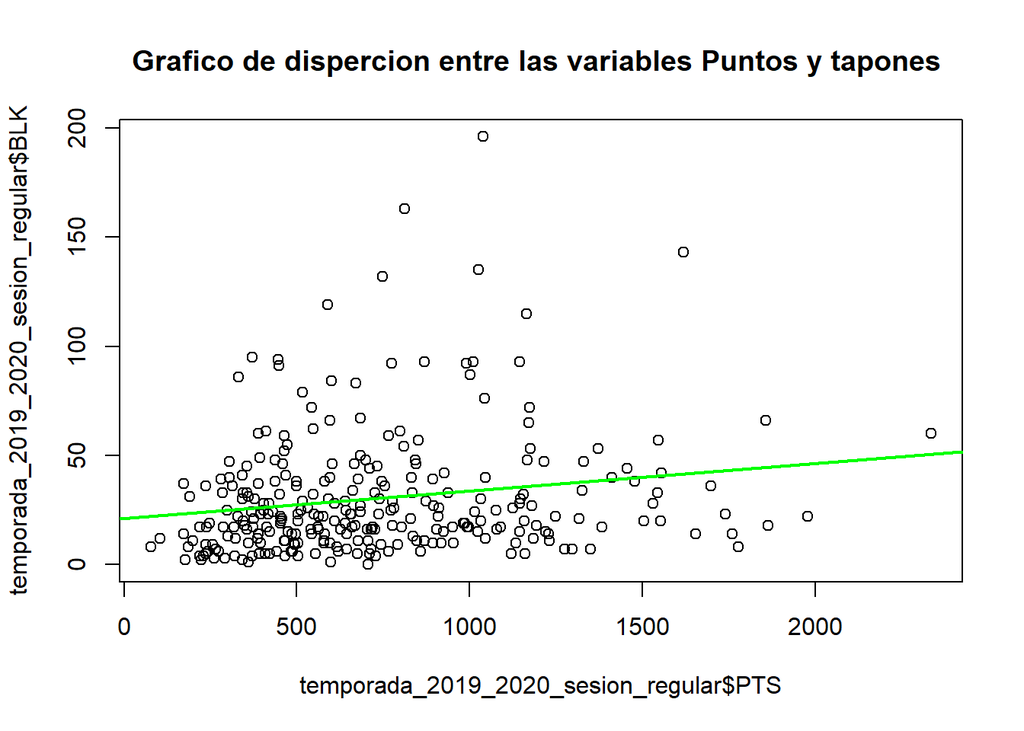

```r
plot(temporada_2019_2020_sesion_regular$PTS,temporada_2019_2020_sesion_regular$BLK,main="Grafico de dispercion entre las variables Puntos y tapones ")
abline(lm(temporada_2019_2020_sesion_regular$BLK ~ temporada_2019_2020_sesion_regular$PTS), col = "green", lwd = 2)#tendencia
```

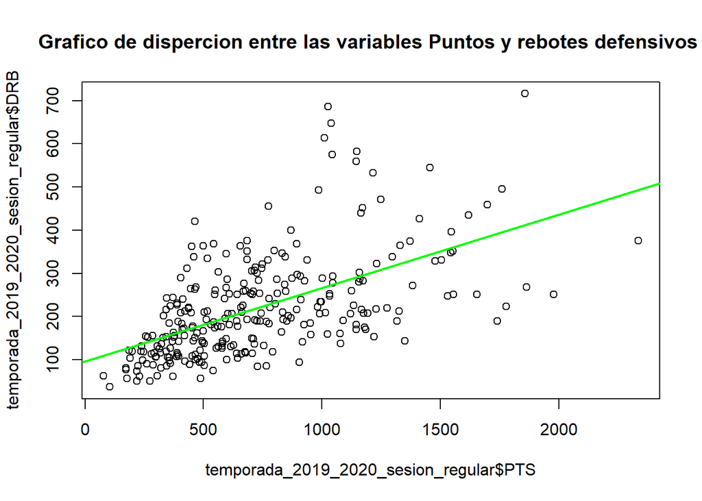

```r
plot(temporada_2019_2020_sesion_regular$PTS,temporada_2019_2020_sesion_regular$DRB,main="Grafico de dispercion entre las variables Puntos y rebotes defensivos ")
abline(lm(temporada_2019_2020_sesion_regular$DRB ~ temporada_2019_2020_sesion_regular$PTS), col = "green", lwd = 2)#tendencia
```

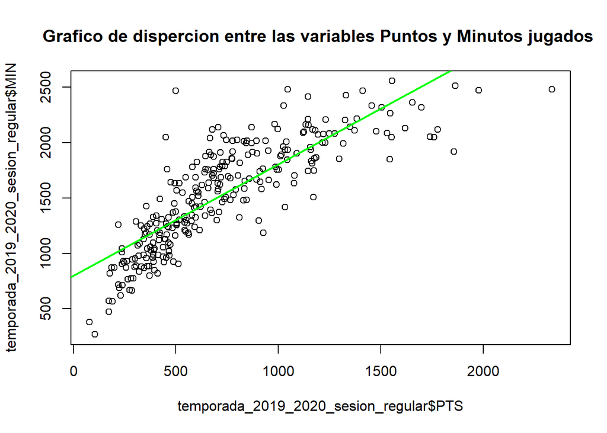

```r
plot(temporada_2019_2020_sesion_regular$PTS,temporada_2019_2020_sesion_regular$MIN,main="Grafico de dispercion entre las variables Puntos y Minutos jugados ")
abline(lm(temporada_2019_2020_sesion_regular$MIN ~ temporada_2019_2020_sesion_regular$PTS), col = "green", lwd = 2)#tendencia
```

Por ultimo, en el siguiente gráfico de dispersión esta relacionado con la segunda temporada 2019-2020 para la sesión playoff(sesión mundial) en el cual se hizo la comparación correspondiente entre cinco variables:rebotes ofensivos, faltas,tapones,rebotes defensivos y minutos jugados con la variable minutos.Tras ello se realizó una correlación y se determino que tan relacionados estas variables para determinar qué jugadores de la NBA tuvieron mayor rendimiento durante en esta temporada. Interpretación del gráfico con mayor correlación es minutos con puntos con 0.8933219 un valor que se aproxima a 1.Concluyendo que entre más minutos jugados en el campo los jugadores obtendrá mayor puntaje.

Las otras variables también llegan a presentar una correlación con la variable puntaje en el cual la mayoría pasa 0.5 como valor de correlación.

```r
cor(temporada_2019_2020_playoff$PTS,temporada_2019_2020_playoff$DRB) # cantidad de rebotes defensivos.
```

```
## [1] 0.847111
```

```r
cor(temporada_2019_2020_playoff$PTS,temporada_2019_2020_playoff$ORB) # rebotes ofensivos.
```

```
## [1] 0.5895173
```

```r
cor(temporada_2019_2020_playoff$PTS,temporada_2019_2020_playoff$PF)  # faltas personales.
```

```
## [1] 0.6453629
```

```r
cor(temporada_2019_2020_playoff$PTS,temporada_2019_2020_playoff$BLK) # numero de tapones
```

```
## [1] 0.6156795
```

```r
cor(temporada_2019_2020_playoff$PTS,temporada_2019_2020_playoff$MIN) # minutos jugados.
```

```
## [1] 0.8933219
```

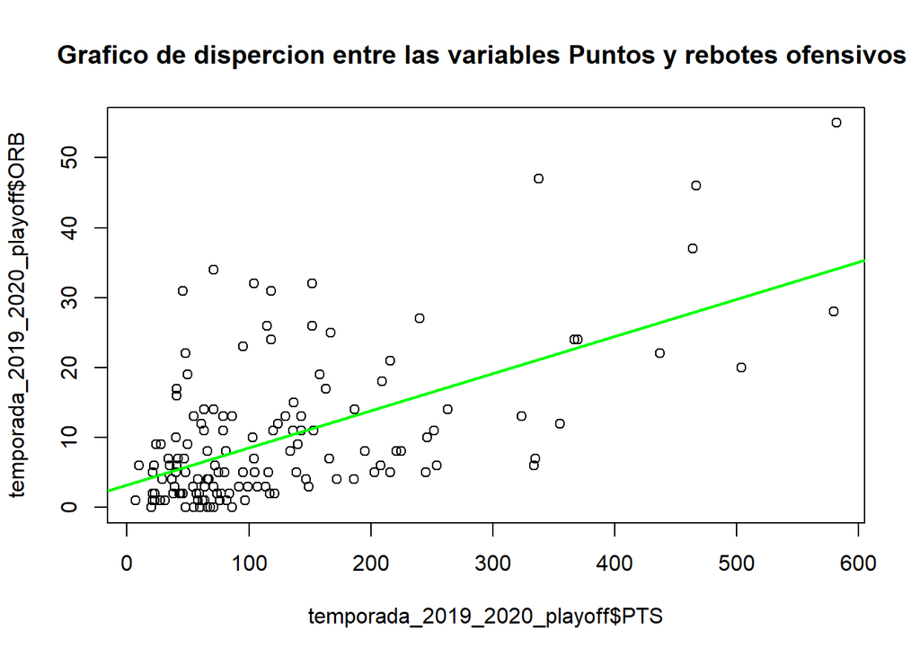

```r
plot(temporada_2019_2020_playoff$PTS,temporada_2019_2020_playoff$ORB,main="Grafico de dispercion entre las variables Puntos y rebotes ofensivos ")
abline(lm(temporada_2019_2020_playoff$ORB ~ temporada_2019_2020_playoff$PTS), col = "green", lwd = 2)#tendencia
```

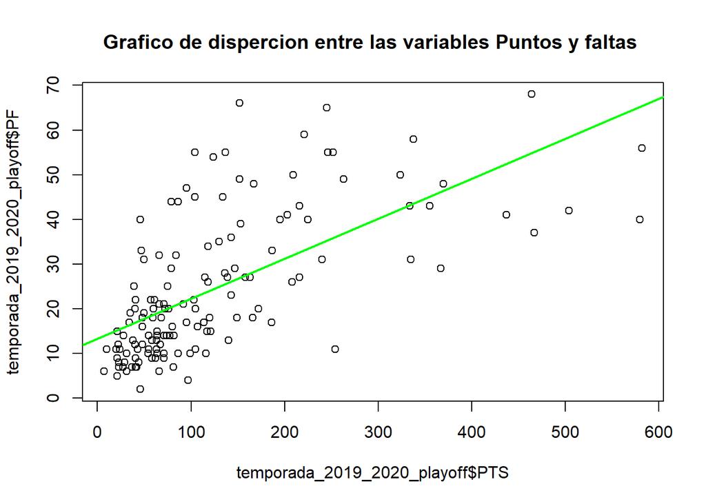

```r
plot(temporada_2019_2020_playoff$PTS,temporada_2019_2020_playoff$PF,main="Grafico de dispercion entre las variables Puntos y faltas ")
abline(lm(temporada_2019_2020_playoff$PF ~ temporada_2019_2020_playoff$PTS), col = "green", lwd = 2)#tendencia
```

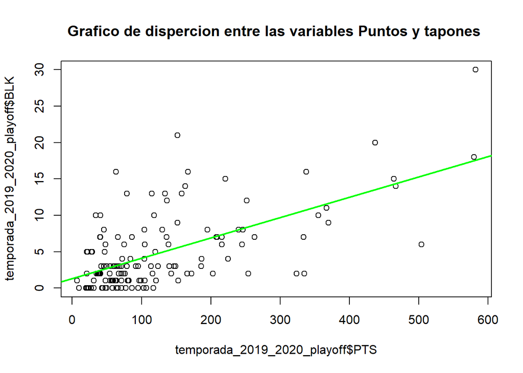

```r
plot(temporada_2019_2020_playoff$PTS,temporada_2019_2020_playoff$BLK,main="Grafico de dispercion entre las variables Puntos y tapones ")
abline(lm(temporada_2019_2020_playoff$BLK ~ temporada_2019_2020_playoff$PTS), col = "green", lwd = 2)#tendencia
```

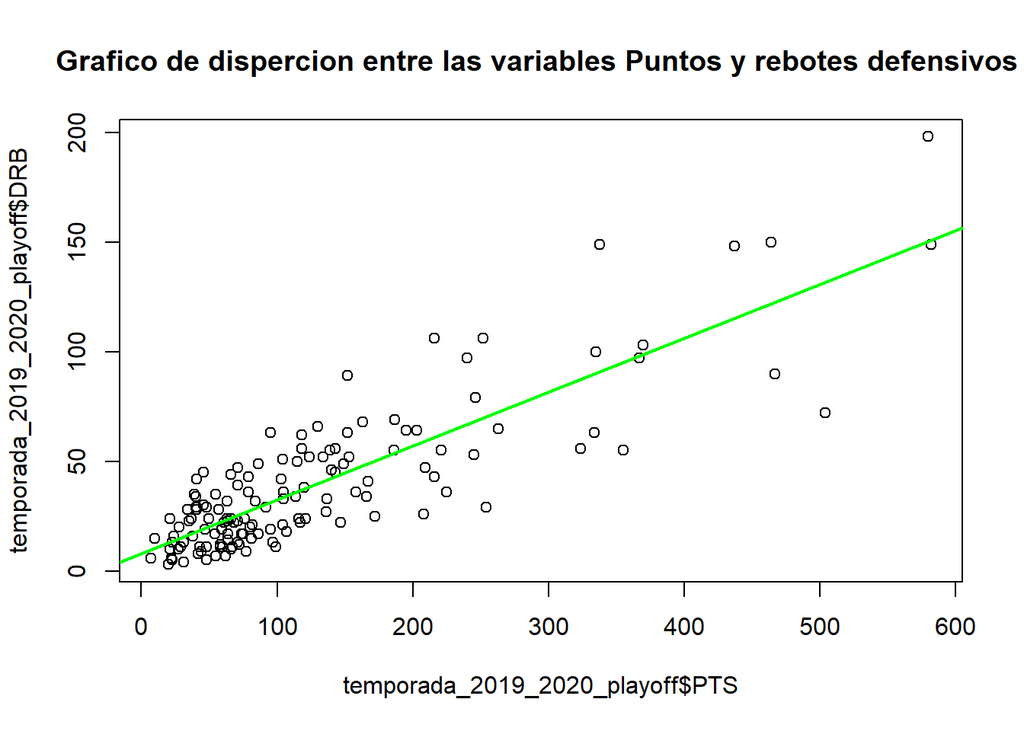

```r
plot(temporada_2019_2020_playoff$PTS,temporada_2019_2020_playoff$DRB,main="Grafico de dispercion entre las variables Puntos y rebotes defensivos ")
abline(lm(temporada_2019_2020_playoff$DRB ~ temporada_2019_2020_playoff$PTS), col = "green", lwd = 2)#tendencia
```

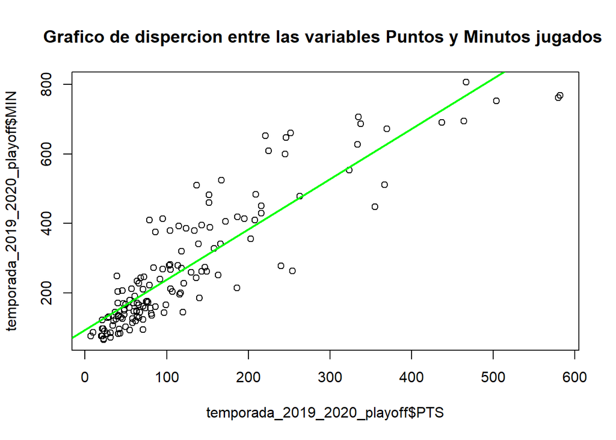

```r
plot(temporada_2019_2020_playoff$PTS,temporada_2019_2020_playoff$MIN,main="Grafico de dispercion entre las variables Puntos y Minutos jugados ")
abline(lm(temporada_2019_2020_playoff$MIN ~ temporada_2019_2020_playoff$PTS), col = "green", lwd = 2)#tendencia
```

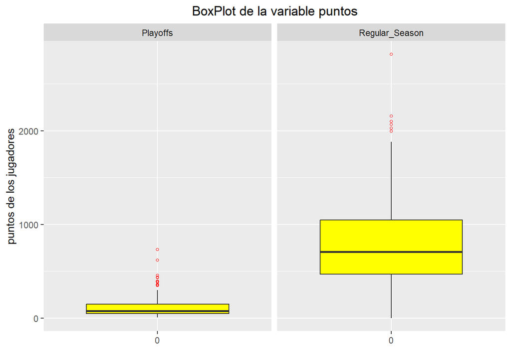

```r
# ------------ Los puntos mas altos en la temporada 2018 - 2019 ------------
ggplot(temporada_2018_2019,aes(x=factor(0),y=PTS)) + geom_boxplot(outlier.colour = "red",outlier.shape = 1,outlier.size=1,fill="yellow") + labs(title = "                                       BoxPlot de la variable puntos",x="",y="puntos de los jugadores") + facet_wrap("Stage")
```

```r
boxplot.stats(temporada_2018_2019_sesion_regular$PTS)$out
```

```
## [1] 2818 2159 2102 2099 2067 2027 1994
```

```r
boxplot.stats(temporada_2018_2019_playoff$PTS)$out
```

```
##  [1] 732 620 455 435 430 395 387 383 361 352 348
```

```r
temporada_2018_2019_sesion_regular %>% arrange(-PTS)
```

| Season | Stage | Player | Team | GP | MIN | FGM | FGA | 3PM | 3PA | FTM | FTA | TOV | PF | ORB | DRB | REB | AST | STL | BLK | PTS | height_cm | weight_kg | nationality | high_school | Edad |
| --- | --- | --- | --- | --- | --- | --- | --- | --- | --- | --- | --- | --- | --- | --- | --- | --- | --- | --- | --- | --- | --- | --- | --- | --- | --- |
| 2018 - 2019 | Regular_Season | James Harden | HOU | 78 | 2866.7 | 843 | 1909 | 378 | 1028 | 754 | 858 | 387 | 244 | 66 | 452 | 518 | 586 | 158 | 58 | 2818 | 196 | 100 | United States | Artesia High School | 31 |
| 2018 - 2019 | Regular_Season | Paul George | OKC | 77 | 2841.4 | 707 | 1614 | 292 | 757 | 453 | 540 | 205 | 214 | 105 | 523 | 628 | 318 | 170 | 34 | 2159 | 206 | 100 | United States | Pete Knight High School | 30 |
| 2018 - 2019 | Regular_Season | Kemba Walker | CHA | 82 | 2862.6 | 731 | 1684 | 260 | 731 | 380 | 450 | 211 | 131 | 52 | 309 | 361 | 484 | 102 | 34 | 2102 | 185 | 83 | United States | Rice High School | 30 |
| 2018 - 2019 | Regular_Season | Bradley Beal | WAS | 82 | 3027.8 | 764 | 1609 | 209 | 596 | 362 | 448 | 224 | 226 | 89 | 322 | 411 | 448 | 121 | 58 | 2099 | 191 | 94 | United States | Chaminade College Preparatory School | 27 |
| 2018 - 2019 | Regular_Season | Damian Lillard | POR | 80 | 2837.9 | 681 | 1533 | 237 | 643 | 468 | 513 | 212 | 148 | 68 | 303 | 371 | 551 | 88 | 34 | 2067 | 191 | 88 | United States | Oakland High School | 30 |
| 2018 - 2019 | Regular_Season | Kevin Durant | GSW | 78 | 2701.6 | 721 | 1383 | 137 | 388 | 448 | 506 | 225 | 155 | 33 | 464 | 497 | 457 | 58 | 84 | 2027 | 206 | 109 | United States | Montrose Christian School | 32 |
| 2018 - 2019 | Regular_Season | Giannis Antetokounmpo | MIL | 72 | 2358.4 | 721 | 1247 | 52 | 203 | 500 | 686 | 268 | 232 | 159 | 739 | 898 | 424 | 92 | 110 | 1994 | 211 | 110 | Greece / Nigeria | NA | 26 |
| 2018 - 2019 | Regular_Season | Stephen Curry | GSW | 69 | 2331.3 | 632 | 1340 | 354 | 810 | 263 | 287 | 192 | 166 | 45 | 324 | 369 | 361 | 92 | 25 | 1881 | 191 | 86 | United States | Charlotte Christian School | 32 |
| 2018 - 2019 | Regular_Season | Karl-Anthony Towns | MIN | 77 | 2544.7 | 681 | 1314 | 142 | 355 | 376 | 450 | 240 | 292 | 263 | 691 | 954 | 259 | 67 | 125 | 1880 | 213 | 112 | United States / Dominican Republic | St. Joseph High School | 25 |
| 2018 - 2019 | Regular_Season | Blake Griffin | DET | 75 | 2622.4 | 619 | 1341 | 189 | 522 | 414 | 550 | 253 | 199 | 100 | 465 | 565 | 402 | 52 | 28 | 1841 | 208 | 113 | United States | Oklahoma Christian School | 31 |

[output cut: 282 more lines]

```r
temporada_2018_2019_playoff %>% arrange(-PTS)
```

| Season | Stage | Player | Team | GP | MIN | FGM | FGA | 3PM | 3PA | FTM | FTA | TOV | PF | ORB | DRB | REB | AST | STL | BLK | PTS | height_cm | weight_kg | nationality | high_school | Edad |
| --- | --- | --- | --- | --- | --- | --- | --- | --- | --- | --- | --- | --- | --- | --- | --- | --- | --- | --- | --- | --- | --- | --- | --- | --- | --- |
| 2018 - 2019 | Playoffs | Kawhi Leonard | TOR | 24 | 939.5 | 243 | 496 | 55 | 145 | 191 | 216 | 74 | 56 | 54 | 164 | 218 | 94 | 40 | 17 | 732 | 201 | 104 | United States | Martin Luther King High School | 29 |
| 2018 - 2019 | Playoffs | Stephen Curry | GSW | 22 | 845.6 | 190 | 431 | 92 | 244 | 148 | 157 | 66 | 68 | 17 | 115 | 132 | 126 | 24 | 4 | 620 | 191 | 86 | United States | Charlotte Christian School | 32 |
| 2018 - 2019 | Playoffs | Pascal Siakam | TOR | 24 | 891.3 | 180 | 383 | 29 | 104 | 66 | 87 | 33 | 67 | 39 | 131 | 170 | 66 | 25 | 17 | 455 | 206 | 104 | Cameroon | God's Academy | 26 |
| 2018 - 2019 | Playoffs | Klay Thompson | GSW | 21 | 818.0 | 164 | 360 | 70 | 158 | 37 | 41 | 38 | 59 | 12 | 74 | 86 | 44 | 28 | 15 | 435 | 201 | 98 | United States | Santa Margarita Catholic High School | 30 |
| 2018 - 2019 | Playoffs | Damian Lillard | POR | 16 | 650.1 | 138 | 330 | 59 | 158 | 95 | 114 | 60 | 40 | 8 | 68 | 76 | 106 | 27 | 5 | 430 | 191 | 88 | United States | Oakland High School | 30 |
| 2018 - 2019 | Playoffs | C.J. McCollum | POR | 16 | 635.5 | 154 | 350 | 46 | 117 | 41 | 56 | 30 | 34 | 14 | 66 | 80 | 59 | 13 | 10 | 395 | 191 | 86 | United States | Glen Oak High School | 29 |
| 2018 - 2019 | Playoffs | Kevin Durant | GSW | 12 | 441.7 | 125 | 243 | 35 | 80 | 102 | 113 | 43 | 38 | 1 | 58 | 59 | 54 | 13 | 12 | 387 | 206 | 109 | United States | Montrose Christian School | 32 |
| 2018 - 2019 | Playoffs | Giannis Antetokounmpo | MIL | 15 | 513.9 | 129 | 262 | 18 | 55 | 107 | 168 | 50 | 48 | 37 | 147 | 184 | 73 | 17 | 30 | 383 | 211 | 110 | Greece / Nigeria | NA | 26 |
| 2018 - 2019 | Playoffs | Kyle Lowry | TOR | 24 | 900.5 | 122 | 278 | 52 | 145 | 65 | 81 | 53 | 96 | 21 | 96 | 117 | 159 | 31 | 7 | 361 | 185 | 89 | United States | Cardinal Dougherty High School | 34 |
| 2018 - 2019 | Playoffs | Nikola Jokic | DEN | 14 | 556.5 | 132 | 261 | 22 | 56 | 66 | 78 | 36 | 54 | 54 | 128 | 182 | 118 | 16 | 13 | 352 | 213 | 113 | Serbia | NA | 25 |

[output cut: 133 more lines]

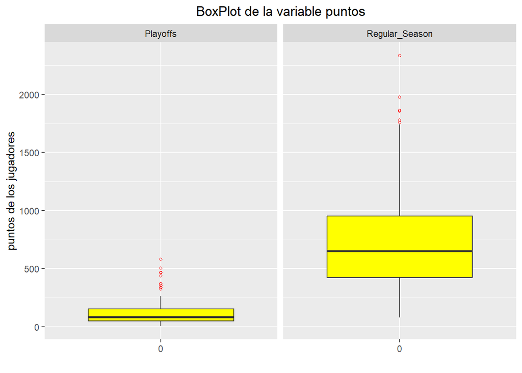

```r
# ------------ Los puntos mas altos en la temporada 2019 - 2020 ------------
ggplot(temporada_2019_2020,aes(x=factor(0),y=PTS)) + geom_boxplot(outlier.colour = "red",outlier.shape = 1,outlier.size=1,fill="yellow") + labs(title = "                                       BoxPlot de la variable puntos",x="",y="puntos de los jugadores") + facet_wrap("Stage")
```

```r
boxplot.stats(temporada_2019_2020_sesion_regular$PTS)$out
```

```
## [1] 2335 1978 1863 1857 1778 1759
```

```r
boxplot.stats(temporada_2019_2020_playoff$PTS)$out
```

```
##  [1] 582 580 504 467 464 437 370 367 355 338 335 334 324
```

```r
temporada_2019_2020_sesion_regular %>% arrange(-PTS)
```

| Season | Stage | Player | Team | GP | MIN | FGM | FGA | 3PM | 3PA | FTM | FTA | TOV | PF | ORB | DRB | REB | AST | STL | BLK | PTS | height_cm | weight_kg | nationality | high_school | Edad |
| --- | --- | --- | --- | --- | --- | --- | --- | --- | --- | --- | --- | --- | --- | --- | --- | --- | --- | --- | --- | --- | --- | --- | --- | --- | --- |
| 2019 - 2020 | Regular_Season | James Harden | HOU | 68 | 2482.6 | 672 | 1514 | 299 | 843 | 692 | 800 | 308 | 227 | 70 | 376 | 446 | 512 | 125 | 60 | 2335 | 196 | 100 | United States | Artesia High School | 31 |
| 2019 - 2020 | Regular_Season | Damian Lillard | POR | 66 | 2473.7 | 624 | 1349 | 270 | 674 | 460 | 518 | 194 | 114 | 33 | 251 | 284 | 530 | 70 | 22 | 1978 | 191 | 88 | United States | Oakland High School | 30 |
| 2019 - 2020 | Regular_Season | Devin Booker | PHX | 70 | 2511.8 | 627 | 1283 | 141 | 398 | 468 | 509 | 264 | 213 | 29 | 268 | 297 | 456 | 49 | 18 | 1863 | 198 | 93 | United States | Moss Point High School | 24 |
| 2019 - 2020 | Regular_Season | Giannis Antetokounmpo | MIL | 63 | 1916.9 | 685 | 1238 | 89 | 293 | 398 | 629 | 230 | 195 | 140 | 716 | 856 | 354 | 61 | 66 | 1857 | 211 | 110 | Greece / Nigeria | NA | 26 |
| 2019 - 2020 | Regular_Season | Trae Young | ATL | 60 | 2120.1 | 546 | 1249 | 205 | 568 | 481 | 559 | 289 | 104 | 32 | 223 | 255 | 560 | 65 | 8 | 1778 | 188 | 82 | United States | Norman High School | 22 |
| 2019 - 2020 | Regular_Season | Luka Doncic | DAL | 61 | 2047.3 | 581 | 1255 | 171 | 541 | 426 | 562 | 260 | 153 | 78 | 495 | 573 | 538 | 60 | 14 | 1759 | 201 | 99 | Slovenia | NA | 21 |
| 2019 - 2020 | Regular_Season | Bradley Beal | WAS | 57 | 2053.2 | 593 | 1303 | 170 | 481 | 385 | 457 | 194 | 126 | 52 | 190 | 242 | 347 | 71 | 23 | 1741 | 191 | 94 | United States | Chaminade College Preparatory School | 27 |
| 2019 - 2020 | Regular_Season | LeBron James | LAL | 67 | 2316.3 | 643 | 1303 | 148 | 425 | 264 | 381 | 261 | 118 | 66 | 459 | 525 | 684 | 78 | 36 | 1698 | 203 | 113 | United States | St. Vincent St. Mary High School | 36 |
| 2019 - 2020 | Regular_Season | Donovan Mitchell | UTA | 69 | 2364.0 | 602 | 1342 | 173 | 473 | 278 | 322 | 184 | 172 | 53 | 251 | 304 | 294 | 70 | 14 | 1655 | 191 | 98 | United States | Brewster Academy | 24 |
| 2019 - 2020 | Regular_Season | Anthony Davis | LAL | 62 | 2131.4 | 551 | 1096 | 72 | 218 | 444 | 525 | 154 | 156 | 142 | 435 | 577 | 200 | 91 | 143 | 1618 | 208 | 115 | United States | Perspectives Charter Academy | 27 |

[output cut: 270 more lines]

```r
temporada_2019_2020_playoff %>% arrange(-PTS)
```

| Season | Stage | Player | Team | GP | MIN | FGM | FGA | 3PM | 3PA | FTM | FTA | TOV | PF | ORB | DRB | REB | AST | STL | BLK | PTS | height_cm | weight_kg | nationality | high_school | Edad |
| --- | --- | --- | --- | --- | --- | --- | --- | --- | --- | --- | --- | --- | --- | --- | --- | --- | --- | --- | --- | --- | --- | --- | --- | --- | --- |
| 2019 - 2020 | Playoffs | Anthony Davis | LAL | 21 | 768.9 | 205 | 359 | 23 | 60 | 149 | 179 | 53 | 56 | 55 | 149 | 204 | 73 | 26 | 30 | 582 | 208 | 115 | United States | Perspectives Charter Academy | 27 |
| 2019 - 2020 | Playoffs | LeBron James | LAL | 21 | 761.7 | 214 | 382 | 44 | 119 | 108 | 150 | 84 | 40 | 28 | 198 | 226 | 184 | 25 | 18 | 580 | 203 | 113 | United States | St. Vincent St. Mary High School | 36 |
| 2019 - 2020 | Playoffs | Jamal Murray | DEN | 19 | 753.0 | 186 | 368 | 62 | 137 | 70 | 78 | 53 | 42 | 20 | 72 | 92 | 126 | 18 | 6 | 504 | 193 | 94 | Canada | Athlete Institute Prep | 23 |
| 2019 - 2020 | Playoffs | Jimmy Butler | MIA | 21 | 806.5 | 144 | 295 | 15 | 43 | 164 | 191 | 59 | 37 | 46 | 90 | 136 | 127 | 41 | 14 | 467 | 203 | 105 | United States | Tomball High School | 31 |
| 2019 - 2020 | Playoffs | Nikola Jokic | DEN | 19 | 694.4 | 178 | 343 | 42 | 98 | 66 | 79 | 62 | 68 | 37 | 150 | 187 | 109 | 20 | 15 | 464 | 213 | 113 | Serbia | NA | 25 |
| 2019 - 2020 | Playoffs | Jayson Tatum | BOS | 17 | 690.3 | 145 | 334 | 47 | 126 | 100 | 123 | 48 | 41 | 22 | 148 | 170 | 85 | 17 | 20 | 437 | 203 | 94 | United States | Chaminade College Preparatory School | 22 |
| 2019 - 2020 | Playoffs | Jaylen Brown | BOS | 17 | 672.0 | 137 | 288 | 43 | 120 | 53 | 63 | 41 | 48 | 24 | 103 | 127 | 39 | 26 | 9 | 370 | 201 | 100 | United States | Joseph Wheeler High School | 24 |
| 2019 - 2020 | Playoffs | Kawhi Leonard | LAC | 13 | 510.9 | 131 | 268 | 24 | 73 | 81 | 94 | 33 | 29 | 24 | 97 | 121 | 72 | 30 | 11 | 367 | 201 | 104 | United States | Martin Luther King High School | 29 |
| 2019 - 2020 | Playoffs | James Harden | HOU | 12 | 447.8 | 109 | 228 | 39 | 117 | 98 | 116 | 45 | 43 | 12 | 55 | 67 | 92 | 18 | 10 | 355 | 196 | 100 | United States | Artesia High School | 31 |
| 2019 - 2020 | Playoffs | Bam Adebayo | MIA | 19 | 687.1 | 124 | 220 | 0 | 1 | 90 | 115 | 47 | 58 | 47 | 149 | 196 | 84 | 19 | 16 | 338 | 208 | 116 | United States | High Point Christian Academy | 23 |

[output cut: 130 more lines]

## **Segundo objetivo**

Según el primer histograma, presenta “Valor relativo del jugador en la sesión regular de la temporada 2018-2019” el cual se considero el numero de puntos alcanzados que se considero a partir de las variables(cantidad de minutos,cantidad de faltas,cantidad de rebotes defensivos,cantidad de rebotes ofensivos,cantidad tapones,cantidad de puntos) y consigo determinar el nivel que le corresponde acorde a su desempeño con un rol de malo hasta champions, segun su desempaño en diferentes ambitos del juego de la liga NBA.

Evaluando a los mejores jugadores que fueron determinados anteriormente por medio del diagrama de caja se deduce que:

El jugador que mayor sobresalió que fue James ocupa el nivel 5 tomando el termino de Leyenda.

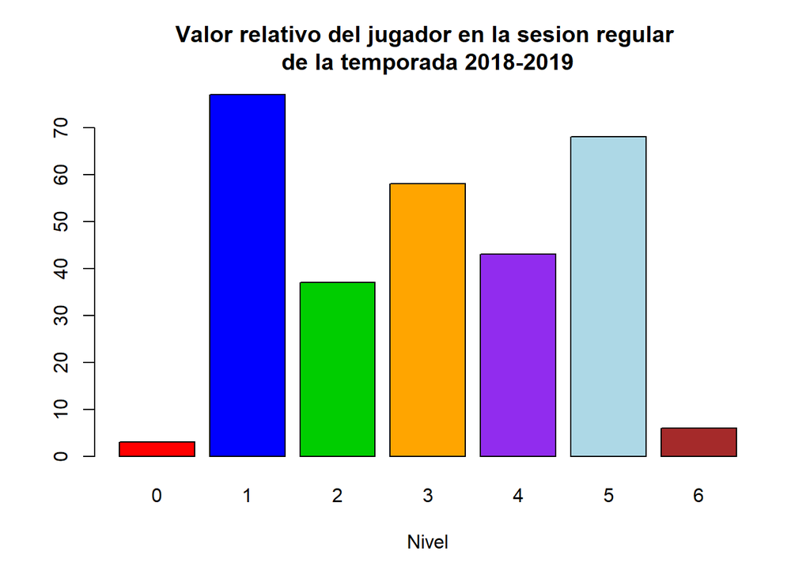

```r
# En base a los descriptores, realizaremos una medicion en cada aspecto del jugador
# 0 = Decepción, 1 = Novato, 2 = Competente, 3 = Destacado, 4 = Maestro, 5 = Leyenda, 6 = Champion
temporada_2018_2019_sesion_regular$Nivel <- 0
temporada_2018_2019_sesion_regular$Nivel_of <- 0
temporada_2018_2019_sesion_regular$Nivel_de <- 0

for(a in 1:292) {
  if(temporada_2018_2019_sesion_regular$MIN[a] >= mediana_cant_min_RS_18_19) { # cantidad de minutos
    temporada_2018_2019_sesion_regular$Nivel[a] <- temporada_2018_2019_sesion_regular$Nivel[a] + 1
    temporada_2018_2019_sesion_regular$Nivel_of[a] <- temporada_2018_2019_sesion_regular$Nivel_of[a] + 1
  }
  if((temporada_2018_2019_sesion_regular$PF[a] <= mediana_faltas_RS_18_19)& (temporada_2018_2019_sesion_regular$PF[a] | 0)) {  # cantidad de faltas
    temporada_2018_2019_sesion_regular$Nivel[a] <- temporada_2018_2019_sesion_regular$Nivel[a] + 1
    temporada_2018_2019_sesion_regular$Nivel_de[a] <- temporada_2018_2019_sesion_regular$Nivel_de[a] + 1
  }
  if(temporada_2018_2019_sesion_regular$DRB[a] >= mediana_RebDef_RS_18_19) { # cantidad de rebotes defensivos
    temporada_2018_2019_sesion_regular$Nivel[a] <- temporada_2018_2019_sesion_regular$Nivel[a] + 1
    temporada_2018_2019_sesion_regular$Nivel_de[a] <- temporada_2018_2019_sesion_regular$Nivel_de[a] + 1
  }
  if(temporada_2018_2019_sesion_regular$ORB[a] >= mediana_RebOf_RS_18_19) { # cantidad de rebotes ofensivos
    temporada_2018_2019_sesion_regular$Nivel[a] <- temporada_2018_2019_sesion_regular$Nivel[a] + 1
    temporada_2018_2019_sesion_regular$Nivel_of[a] <- temporada_2018_2019_sesion_regular$Nivel_of[a] + 1
  }
  if(temporada_2018_2019_sesion_regular$BLK[a] >= mediana_tapones_RS_18_19) {           # cantidad tapones
    temporada_2018_2019_sesion_regular$Nivel[a] <- temporada_2018_2019_sesion_regular$Nivel[a] + 1
    temporada_2018_2019_sesion_regular$Nivel_de[a] <- temporada_2018_2019_sesion_regular$Nivel_de[a] + 1
  }
  if(temporada_2018_2019_sesion_regular$PTS[a] >= mediana_PTS_RS_18_19) {   # cantidad de puntos
    temporada_2018_2019_sesion_regular$Nivel[a] <- temporada_2018_2019_sesion_regular$Nivel[a] + 1
    temporada_2018_2019_sesion_regular$Nivel_of[a] <- temporada_2018_2019_sesion_regular$Nivel_of[a] + 1
  }
}

barplot(table(temporada_2018_2019_sesion_regular$Nivel), col=c("red", "blue", "green3", "orange", "purple2", "lightblue", "brown"),
        xlab="Nivel", main="Valor relativo del jugador en la sesion regular
de la temporada 2018-2019")
```

```r
#niveles <- c("Decepción", "Bajo rendimiento", "Competente", "Destacado", "Maestro", "Leyenda", "Champion")

temporada_2018_2019_sesion_regular
```

| Season | Stage | Player | Team | GP | MIN | FGM | FGA | 3PM | 3PA | FTM | FTA | TOV | PF | ORB | DRB | REB | AST | STL | BLK | PTS | height_cm | weight_kg | nationality | high_school | Edad | Nivel | Nivel_of | Nivel_de |
| --- | --- | --- | --- | --- | --- | --- | --- | --- | --- | --- | --- | --- | --- | --- | --- | --- | --- | --- | --- | --- | --- | --- | --- | --- | --- | --- | --- | --- |
| 2018 - 2019 | Regular_Season | James Harden | HOU | 78 | 2866.7 | 843 | 1909 | 378 | 1028 | 754 | 858 | 387 | 244 | 66 | 452 | 518 | 586 | 158 | 58 | 2818 | 196 | 100 | United States | Artesia High School | 31 | 5 | 3 | 2 |
| 2018 - 2019 | Regular_Season | Paul George | OKC | 77 | 2841.4 | 707 | 1614 | 292 | 757 | 453 | 540 | 205 | 214 | 105 | 523 | 628 | 318 | 170 | 34 | 2159 | 206 | 100 | United States | Pete Knight High School | 30 | 5 | 3 | 2 |
| 2018 - 2019 | Regular_Season | Kemba Walker | CHA | 82 | 2862.6 | 731 | 1684 | 260 | 731 | 380 | 450 | 211 | 131 | 52 | 309 | 361 | 484 | 102 | 34 | 2102 | 185 | 83 | United States | Rice High School | 30 | 5 | 2 | 3 |
| 2018 - 2019 | Regular_Season | Bradley Beal | WAS | 82 | 3027.8 | 764 | 1609 | 209 | 596 | 362 | 448 | 224 | 226 | 89 | 322 | 411 | 448 | 121 | 58 | 2099 | 191 | 94 | United States | Chaminade College Preparatory School | 27 | 5 | 3 | 2 |
| 2018 - 2019 | Regular_Season | Damian Lillard | POR | 80 | 2837.9 | 681 | 1533 | 237 | 643 | 468 | 513 | 212 | 148 | 68 | 303 | 371 | 551 | 88 | 34 | 2067 | 191 | 88 | United States | Oakland High School | 30 | 5 | 3 | 2 |
| 2018 - 2019 | Regular_Season | Kevin Durant | GSW | 78 | 2701.6 | 721 | 1383 | 137 | 388 | 448 | 506 | 225 | 155 | 33 | 464 | 497 | 457 | 58 | 84 | 2027 | 206 | 109 | United States | Montrose Christian School | 32 | 4 | 2 | 2 |
| 2018 - 2019 | Regular_Season | Giannis Antetokounmpo | MIL | 72 | 2358.4 | 721 | 1247 | 52 | 203 | 500 | 686 | 268 | 232 | 159 | 739 | 898 | 424 | 92 | 110 | 1994 | 211 | 110 | Greece / Nigeria | NA | 26 | 5 | 3 | 2 |
| 2018 - 2019 | Regular_Season | Stephen Curry | GSW | 69 | 2331.3 | 632 | 1340 | 354 | 810 | 263 | 287 | 192 | 166 | 45 | 324 | 369 | 361 | 92 | 25 | 1881 | 191 | 86 | United States | Charlotte Christian School | 32 | 3 | 2 | 1 |
| 2018 - 2019 | Regular_Season | Karl-Anthony Towns | MIN | 77 | 2544.7 | 681 | 1314 | 142 | 355 | 376 | 450 | 240 | 292 | 263 | 691 | 954 | 259 | 67 | 125 | 1880 | 213 | 112 | United States / Dominican Republic | St. Joseph High School | 25 | 5 | 3 | 2 |
| 2018 - 2019 | Regular_Season | Blake Griffin | DET | 75 | 2622.4 | 619 | 1341 | 189 | 522 | 414 | 550 | 253 | 199 | 100 | 465 | 565 | 402 | 52 | 28 | 1841 | 208 | 113 | United States | Oklahoma Christian School | 31 | 5 | 3 | 2 |

[output cut: 282 more lines]

Según el segundo histograma, presenta “Valor relativo del jugador en el Playoff de la temporada 2018-2019” el cual se considero el numero de puntos alcanzados que se considero a partir de las variables(cantidad de minutos,cantidad de faltas,cantidad de rebotes defensivos,cantidad de rebotes ofensivos,cantidad tapones,cantidad de puntos) y consigo determinar el nivel que le corresponde acorde a su desempeño con un rol de malo hasta champions, segun su desempaño en diferentes ambitos del juego de la liga NBA.

Evaluando a los mejores jugadores que fueron determinados anteriormente por medio del diagrama de caja se dedujo que:

El jugador que mayor sobresalió que fue Kawhi Leonard ocupa el nivel 5 tomando el termino de Leyenda.

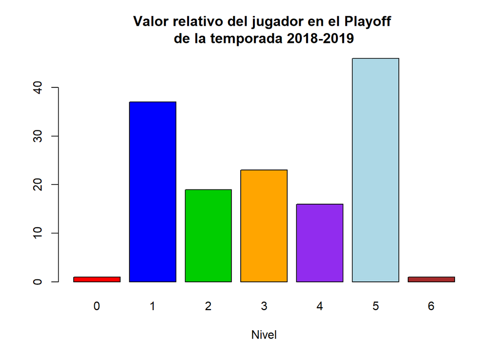

```r
# En base a los descriptores, realizaremos una medicion en cada aspecto del jugador
# 0 = Decepción, 1 = Novato, 2 = Competente, 3 = Destacado, 4 = Maestro, 5 = Leyenda, 6 = Champion
temporada_2018_2019_playoff$Nivel <- 0
temporada_2018_2019_playoff$Nivel_of <- 0
temporada_2018_2019_playoff$Nivel_de <- 0

for(a in 1:143) {
  if(temporada_2018_2019_playoff$MIN[a] >= mediana_cant_min_PO_18_19) { # cantidad de minutos
    temporada_2018_2019_playoff$Nivel[a] <- temporada_2018_2019_playoff$Nivel[a] + 1
    temporada_2018_2019_playoff$Nivel_of[a] <- temporada_2018_2019_playoff$Nivel_of[a] + 1
  }
  if((temporada_2018_2019_playoff$PF[a] <= mediana_faltas_PO_18_19)& (temporada_2018_2019_playoff$PF[a] | 0)) {  # cantidad de faltas
    temporada_2018_2019_playoff$Nivel[a] <- temporada_2018_2019_playoff$Nivel[a] + 1
    temporada_2018_2019_playoff$Nivel_de[a] <- temporada_2018_2019_playoff$Nivel_de[a] + 1
  }
  if(temporada_2018_2019_playoff$DRB[a] >= mediana_RebDef_PO_18_19) { # cantidad de rebotes defensivos
    temporada_2018_2019_playoff$Nivel[a] <- temporada_2018_2019_playoff$Nivel[a] + 1
    temporada_2018_2019_playoff$Nivel_de[a] <- temporada_2018_2019_playoff$Nivel_de[a] + 1
  }
  if(temporada_2018_2019_playoff$ORB[a] >= mediana_RebOf_PO_18_19) { # cantidad de rebotes ofensivos
    temporada_2018_2019_playoff$Nivel[a] <- temporada_2018_2019_playoff$Nivel[a] + 1
    temporada_2018_2019_playoff$Nivel_of[a] <- temporada_2018_2019_playoff$Nivel_of[a] + 1
  }
  if(temporada_2018_2019_playoff$BLK[a] >= mediana_tapones_PO_18_19) {           # cantidad tapones
    temporada_2018_2019_playoff$Nivel[a] <- temporada_2018_2019_playoff$Nivel[a] + 1
    temporada_2018_2019_playoff$Nivel_de[a] <- temporada_2018_2019_playoff$Nivel_de[a] + 1
  }
  if(temporada_2018_2019_playoff$PTS[a] >= mediana_PTS_PO_18_19) {   # cantidad de puntos
    temporada_2018_2019_playoff$Nivel[a] <- temporada_2018_2019_playoff$Nivel[a] + 1
    temporada_2018_2019_playoff$Nivel_of[a] <- temporada_2018_2019_playoff$Nivel_of[a] + 1
  }
}

barplot(table(temporada_2018_2019_playoff$Nivel), col=c("red", "blue", "green3", "orange", "purple2", "lightblue", "brown"),
        xlab="Nivel", main="Valor relativo del jugador en el Playoff
de la temporada 2018-2019")
```

```r
#niveles <- c("Decepción", "Bajo rendimiento", "Competente", "Destacado", "Maestro", "Leyenda", "Champion")

temporada_2018_2019_playoff
```

| Season | Stage | Player | Team | GP | MIN | FGM | FGA | 3PM | 3PA | FTM | FTA | TOV | PF | ORB | DRB | REB | AST | STL | BLK | PTS | height_cm | weight_kg | nationality | high_school | Edad | Nivel | Nivel_of | Nivel_de |
| --- | --- | --- | --- | --- | --- | --- | --- | --- | --- | --- | --- | --- | --- | --- | --- | --- | --- | --- | --- | --- | --- | --- | --- | --- | --- | --- | --- | --- |
| 2018 - 2019 | Playoffs | Kawhi Leonard | TOR | 24 | 939.5 | 243 | 496 | 55 | 145 | 191 | 216 | 74 | 56 | 54 | 164 | 218 | 94 | 40 | 17 | 732 | 201 | 104 | United States | Martin Luther King High School | 29 | 5 | 3 | 2 |
| 2018 - 2019 | Playoffs | Stephen Curry | GSW | 22 | 845.6 | 190 | 431 | 92 | 244 | 148 | 157 | 66 | 68 | 17 | 115 | 132 | 126 | 24 | 4 | 620 | 191 | 86 | United States | Charlotte Christian School | 32 | 5 | 3 | 2 |
| 2018 - 2019 | Playoffs | Pascal Siakam | TOR | 24 | 891.3 | 180 | 383 | 29 | 104 | 66 | 87 | 33 | 67 | 39 | 131 | 170 | 66 | 25 | 17 | 455 | 206 | 104 | Cameroon | God's Academy | 26 | 5 | 3 | 2 |
| 2018 - 2019 | Playoffs | Klay Thompson | GSW | 21 | 818.0 | 164 | 360 | 70 | 158 | 37 | 41 | 38 | 59 | 12 | 74 | 86 | 44 | 28 | 15 | 435 | 201 | 98 | United States | Santa Margarita Catholic High School | 30 | 5 | 3 | 2 |
| 2018 - 2019 | Playoffs | Damian Lillard | POR | 16 | 650.1 | 138 | 330 | 59 | 158 | 95 | 114 | 60 | 40 | 8 | 68 | 76 | 106 | 27 | 5 | 430 | 191 | 88 | United States | Oakland High School | 30 | 5 | 3 | 2 |
| 2018 - 2019 | Playoffs | C.J. McCollum | POR | 16 | 635.5 | 154 | 350 | 46 | 117 | 41 | 56 | 30 | 34 | 14 | 66 | 80 | 59 | 13 | 10 | 395 | 191 | 86 | United States | Glen Oak High School | 29 | 5 | 3 | 2 |
| 2018 - 2019 | Playoffs | Kevin Durant | GSW | 12 | 441.7 | 125 | 243 | 35 | 80 | 102 | 113 | 43 | 38 | 1 | 58 | 59 | 54 | 13 | 12 | 387 | 206 | 109 | United States | Montrose Christian School | 32 | 4 | 2 | 2 |
| 2018 - 2019 | Playoffs | Giannis Antetokounmpo | MIL | 15 | 513.9 | 129 | 262 | 18 | 55 | 107 | 168 | 50 | 48 | 37 | 147 | 184 | 73 | 17 | 30 | 383 | 211 | 110 | Greece / Nigeria | NA | 26 | 5 | 3 | 2 |
| 2018 - 2019 | Playoffs | Kyle Lowry | TOR | 24 | 900.5 | 122 | 278 | 52 | 145 | 65 | 81 | 53 | 96 | 21 | 96 | 117 | 159 | 31 | 7 | 361 | 185 | 89 | United States | Cardinal Dougherty High School | 34 | 5 | 3 | 2 |
| 2018 - 2019 | Playoffs | Nikola Jokic | DEN | 14 | 556.5 | 132 | 261 | 22 | 56 | 66 | 78 | 36 | 54 | 54 | 128 | 182 | 118 | 16 | 13 | 352 | 213 | 113 | Serbia | NA | 25 | 5 | 3 | 2 |

[output cut: 133 more lines]

Según el tercer histograma, presenta “Valor relativo del jugador en la sesión regular de la temporada 2019-2020” el cual se considero el numero de puntos alcanzados que se considero a partir de las variables(cantidad de minutos,cantidad de faltas,cantidad de rebotes defensivos,cantidad de rebotes ofensivos,cantidad tapones,cantidad de puntos) y consigo determinar el nivel que le corresponde acorde a su desempeño con un rol de malo hasta champions, segun su desempaño en diferentes ambitos del juego de la liga NBA.

Evaluando a los mejores jugadores que fueron determinados anteriormente por medio del diagrama de caja se dedujo que:

El jugador que mayor sobresalio que fue James Harden ocupa el nivel 5 tomando el termino de Leyenda

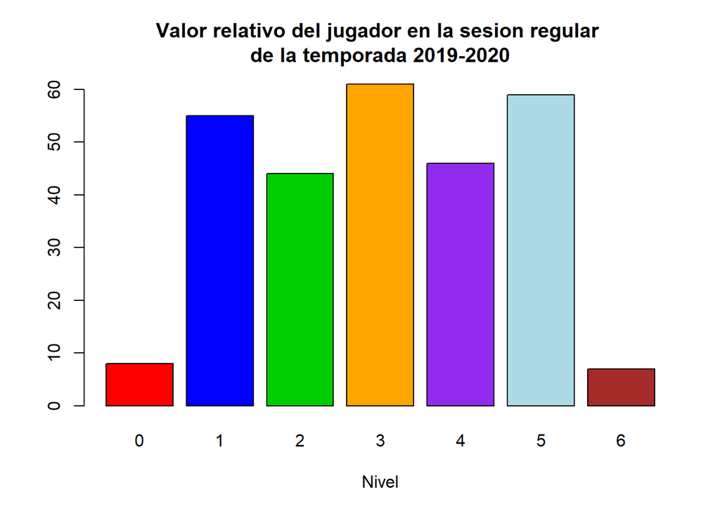

```r
# En base a los descriptores, realizaremos una medicion en cada aspecto del jugador
# 0 = Decepción, 1 = Novato, 2 = Competente, 3 = Destacado, 4 = Maestro, 5 = Leyenda, 6 = Champion
temporada_2019_2020_sesion_regular$Nivel <- 0
temporada_2019_2020_sesion_regular$Nivel_of <- 0
temporada_2019_2020_sesion_regular$Nivel_de <- 0

for(a in 1:280) {
  if(temporada_2019_2020_sesion_regular$MIN[a] >= mediana_cant_min_RS_19_20) { # cantidad de minutos
    temporada_2019_2020_sesion_regular$Nivel[a] <- temporada_2019_2020_sesion_regular$Nivel[a] + 1
    temporada_2019_2020_sesion_regular$Nivel_of[a] <- temporada_2019_2020_sesion_regular$Nivel_of[a] + 1
  }
  if((temporada_2019_2020_sesion_regular$PF[a] <= mediana_faltas_RS_19_20)& (temporada_2018_2019_sesion_regular$PF[a] | 0)) {  # cantidad de faltas
    temporada_2019_2020_sesion_regular$Nivel[a] <- temporada_2019_2020_sesion_regular$Nivel[a] + 1
    temporada_2019_2020_sesion_regular$Nivel_de[a] <- temporada_2019_2020_sesion_regular$Nivel_de[a] + 1
  }
  if(temporada_2019_2020_sesion_regular$DRB[a] >= mediana_RebDef_RS_19_20) { # cantidad de rebotes defensivos
    temporada_2019_2020_sesion_regular$Nivel[a] <- temporada_2019_2020_sesion_regular$Nivel[a] + 1
    temporada_2019_2020_sesion_regular$Nivel_de[a] <- temporada_2019_2020_sesion_regular$Nivel_de[a] + 1
  }
  if(temporada_2019_2020_sesion_regular$ORB[a] >= mediana_RebOf_RS_19_20) { # cantidad de rebotes ofensivos
    temporada_2019_2020_sesion_regular$Nivel[a] <- temporada_2019_2020_sesion_regular$Nivel[a] + 1
    temporada_2019_2020_sesion_regular$Nivel_of[a] <- temporada_2019_2020_sesion_regular$Nivel_of[a] + 1
  }
  if(temporada_2019_2020_sesion_regular$BLK[a] >= mediana_tapones_RS_19_20) {           # cantidad tapones
    temporada_2019_2020_sesion_regular$Nivel[a] <- temporada_2019_2020_sesion_regular$Nivel[a] + 1
    temporada_2019_2020_sesion_regular$Nivel_de[a] <- temporada_2019_2020_sesion_regular$Nivel_de[a] + 1
  }
  if(temporada_2019_2020_sesion_regular$PTS[a] >= mediana_PTS_RS_19_20) {   # cantidad de puntos
    temporada_2019_2020_sesion_regular$Nivel[a] <- temporada_2019_2020_sesion_regular$Nivel[a] + 1
    temporada_2019_2020_sesion_regular$Nivel_of[a] <- temporada_2019_2020_sesion_regular$Nivel_of[a] + 1
  }
}

barplot(table(temporada_2019_2020_sesion_regular$Nivel), col=c("red", "blue", "green3", "orange", "purple2", "lightblue", "brown"),
        xlab="Nivel", main="Valor relativo del jugador en la sesion regular
de la temporada 2019-2020")
```

```r
#niveles <- c("Decepción", "Bajo rendimiento", "Competente", "Destacado", "Maestro", "Leyenda", "Champion")

temporada_2019_2020_sesion_regular
```

| Season | Stage | Player | Team | GP | MIN | FGM | FGA | 3PM | 3PA | FTM | FTA | TOV | PF | ORB | DRB | REB | AST | STL | BLK | PTS | height_cm | weight_kg | nationality | high_school | Edad | Nivel | Nivel_of | Nivel_de |
| --- | --- | --- | --- | --- | --- | --- | --- | --- | --- | --- | --- | --- | --- | --- | --- | --- | --- | --- | --- | --- | --- | --- | --- | --- | --- | --- | --- | --- |
| 2019 - 2020 | Regular_Season | James Harden | HOU | 68 | 2482.6 | 672 | 1514 | 299 | 843 | 692 | 800 | 308 | 227 | 70 | 376 | 446 | 512 | 125 | 60 | 2335 | 196 | 100 | United States | Artesia High School | 31 | 5 | 3 | 2 |
| 2019 - 2020 | Regular_Season | Damian Lillard | POR | 66 | 2473.7 | 624 | 1349 | 270 | 674 | 460 | 518 | 194 | 114 | 33 | 251 | 284 | 530 | 70 | 22 | 1978 | 191 | 88 | United States | Oakland High School | 30 | 5 | 2 | 3 |
| 2019 - 2020 | Regular_Season | Devin Booker | PHX | 70 | 2511.8 | 627 | 1283 | 141 | 398 | 468 | 509 | 264 | 213 | 29 | 268 | 297 | 456 | 49 | 18 | 1863 | 198 | 93 | United States | Moss Point High School | 24 | 3 | 2 | 1 |
| 2019 - 2020 | Regular_Season | Giannis Antetokounmpo | MIL | 63 | 1916.9 | 685 | 1238 | 89 | 293 | 398 | 629 | 230 | 195 | 140 | 716 | 856 | 354 | 61 | 66 | 1857 | 211 | 110 | Greece / Nigeria | NA | 26 | 5 | 3 | 2 |
| 2019 - 2020 | Regular_Season | Trae Young | ATL | 60 | 2120.1 | 546 | 1249 | 205 | 568 | 481 | 559 | 289 | 104 | 32 | 223 | 255 | 560 | 65 | 8 | 1778 | 188 | 82 | United States | Norman High School | 22 | 4 | 2 | 2 |
| 2019 - 2020 | Regular_Season | Luka Doncic | DAL | 61 | 2047.3 | 581 | 1255 | 171 | 541 | 426 | 562 | 260 | 153 | 78 | 495 | 573 | 538 | 60 | 14 | 1759 | 201 | 99 | Slovenia | NA | 21 | 4 | 3 | 1 |
| 2019 - 2020 | Regular_Season | Bradley Beal | WAS | 57 | 2053.2 | 593 | 1303 | 170 | 481 | 385 | 457 | 194 | 126 | 52 | 190 | 242 | 347 | 71 | 23 | 1741 | 191 | 94 | United States | Chaminade College Preparatory School | 27 | 4 | 3 | 1 |
| 2019 - 2020 | Regular_Season | LeBron James | LAL | 67 | 2316.3 | 643 | 1303 | 148 | 425 | 264 | 381 | 261 | 118 | 66 | 459 | 525 | 684 | 78 | 36 | 1698 | 203 | 113 | United States | St. Vincent St. Mary High School | 36 | 6 | 3 | 3 |
| 2019 - 2020 | Regular_Season | Donovan Mitchell | UTA | 69 | 2364.0 | 602 | 1342 | 173 | 473 | 278 | 322 | 184 | 172 | 53 | 251 | 304 | 294 | 70 | 14 | 1655 | 191 | 98 | United States | Brewster Academy | 24 | 4 | 3 | 1 |
| 2019 - 2020 | Regular_Season | Anthony Davis | LAL | 62 | 2131.4 | 551 | 1096 | 72 | 218 | 444 | 525 | 154 | 156 | 142 | 435 | 577 | 200 | 91 | 143 | 1618 | 208 | 115 | United States | Perspectives Charter Academy | 27 | 5 | 3 | 2 |

[output cut: 270 more lines]

Según el cuarto histograma, presenta “Valor relativo del jugador en el Playoff de la temporada 2019-2020” el cual se considero el numero de puntos alcanzados que se considero a partir de las variables(cantidad de minutos,cantidad de faltas,cantidad de rebotes defensivos,cantidad de rebotes ofensivos,cantidad tapones,cantidad de puntos) y consigo determinar el nivel que le corresponde acorde a su desempeño con un rol de malo hasta champions, segun su desempaño en diferentes ambitos del juego de la liga NBA.

Evaluando a los mejores jugadores que fueron determinados anteriormente por medio del diagrama de caja se dedujo que:

El jugador que mayor sobresalio que fue Anthony Davis ocupa el nivel 5 tomando el termino de Leyenda.

[figure not shown]

```r
# En base a los descriptores, realizaremos una medicion en cada aspecto del jugador
# 0 = Decepción, 1 = Novato, 2 = Competente, 3 = Destacado, 4 = Maestro, 5 = Leyenda, 6 = Champion
temporada_2019_2020_playoff$Nivel <- 0
temporada_2019_2020_playoff$Nivel_of <- 0
temporada_2019_2020_playoff$Nivel_de <- 0

for(a in 1:140) {
  if(temporada_2019_2020_playoff$MIN[a] >= mediana_cant_min_PO_19_20) { # cantidad de minutos
    temporada_2019_2020_playoff$Nivel[a] <- temporada_2019_2020_playoff$Nivel[a] + 1
    temporada_2019_2020_playoff$Nivel_of[a] <- temporada_2019_2020_playoff$Nivel_of[a] + 1
  }
  if((temporada_2019_2020_playoff$PF[a] <= mediana_faltas_PO_19_20)& (temporada_2019_2020_playoff$PF[a] | 0)) {  # cantidad de faltas
    temporada_2019_2020_playoff$Nivel[a] <- temporada_2019_2020_playoff$Nivel[a] + 1
    temporada_2019_2020_playoff$Nivel_de[a] <- temporada_2019_2020_playoff$Nivel_de[a] + 1
  }
  if(temporada_2019_2020_playoff$DRB[a] >= mediana_RebDef_PO_19_20) { # cantidad de rebotes defensivos
    temporada_2019_2020_playoff$Nivel[a] <- temporada_2019_2020_playoff$Nivel[a] + 1
    temporada_2019_2020_playoff$Nivel_de[a] <- temporada_2019_2020_playoff$Nivel_de[a] + 1
  }
  if(temporada_2019_2020_playoff$ORB[a] >= mediana_RebOf_PO_19_20) { # cantidad de rebotes ofensivos
    temporada_2019_2020_playoff$Nivel[a] <- temporada_2019_2020_playoff$Nivel[a] + 1
    temporada_2019_2020_playoff$Nivel_of[a] <- temporada_2019_2020_playoff$Nivel_of[a] + 1
  }
  if(temporada_2019_2020_playoff$BLK[a] >= mediana_tapones_PO_19_20) {           # cantidad tapones
    temporada_2019_2020_playoff$Nivel[a] <- temporada_2019_2020_playoff$Nivel[a] + 1
    temporada_2019_2020_playoff$Nivel_de[a] <- temporada_2019_2020_playoff$Nivel_de[a] + 1
  }
  if(temporada_2019_2020_playoff$PTS[a] >= mediana_PTS_PO_19_20) {   # cantidad de puntos
    temporada_2019_2020_playoff$Nivel[a] <- temporada_2019_2020_playoff$Nivel[a] + 1
    temporada_2019_2020_playoff$Nivel_of[a] <- temporada_2019_2020_playoff$Nivel_of[a] + 1
  }
}

barplot(table(temporada_2019_2020_playoff$Nivel), col=c("red", "blue", "green3", "orange", "purple2", "lightblue", "brown"),
        xlab="Nivel", main="Valor relativo del jugador en el Playoff
de la temporada 2018-2019")
```

```r
#niveles <- c("Decepción", "Bajo rendimiento", "Competente", "Destacado", "Maestro", "Leyenda", "Champion")
temporada_2019_2020_playoff
```

| Season | Stage | Player | Team | GP | MIN | FGM | FGA | 3PM | 3PA | FTM | FTA | TOV | PF | ORB | DRB | REB | AST | STL | BLK | PTS | height_cm | weight_kg | nationality | high_school | Edad | Nivel | Nivel_of | Nivel_de |
| --- | --- | --- | --- | --- | --- | --- | --- | --- | --- | --- | --- | --- | --- | --- | --- | --- | --- | --- | --- | --- | --- | --- | --- | --- | --- | --- | --- | --- |
| 2019 - 2020 | Playoffs | Anthony Davis | LAL | 21 | 768.9 | 205 | 359 | 23 | 60 | 149 | 179 | 53 | 56 | 55 | 149 | 204 | 73 | 26 | 30 | 582 | 208 | 115 | United States | Perspectives Charter Academy | 27 | 5 | 3 | 2 |
| 2019 - 2020 | Playoffs | LeBron James | LAL | 21 | 761.7 | 214 | 382 | 44 | 119 | 108 | 150 | 84 | 40 | 28 | 198 | 226 | 184 | 25 | 18 | 580 | 203 | 113 | United States | St. Vincent St. Mary High School | 36 | 5 | 3 | 2 |
| 2019 - 2020 | Playoffs | Jamal Murray | DEN | 19 | 753.0 | 186 | 368 | 62 | 137 | 70 | 78 | 53 | 42 | 20 | 72 | 92 | 126 | 18 | 6 | 504 | 193 | 94 | Canada | Athlete Institute Prep | 23 | 5 | 3 | 2 |
| 2019 - 2020 | Playoffs | Jimmy Butler | MIA | 21 | 806.5 | 144 | 295 | 15 | 43 | 164 | 191 | 59 | 37 | 46 | 90 | 136 | 127 | 41 | 14 | 467 | 203 | 105 | United States | Tomball High School | 31 | 5 | 3 | 2 |
| 2019 - 2020 | Playoffs | Nikola Jokic | DEN | 19 | 694.4 | 178 | 343 | 42 | 98 | 66 | 79 | 62 | 68 | 37 | 150 | 187 | 109 | 20 | 15 | 464 | 213 | 113 | Serbia | NA | 25 | 5 | 3 | 2 |
| 2019 - 2020 | Playoffs | Jayson Tatum | BOS | 17 | 690.3 | 145 | 334 | 47 | 126 | 100 | 123 | 48 | 41 | 22 | 148 | 170 | 85 | 17 | 20 | 437 | 203 | 94 | United States | Chaminade College Preparatory School | 22 | 5 | 3 | 2 |
| 2019 - 2020 | Playoffs | Jaylen Brown | BOS | 17 | 672.0 | 137 | 288 | 43 | 120 | 53 | 63 | 41 | 48 | 24 | 103 | 127 | 39 | 26 | 9 | 370 | 201 | 100 | United States | Joseph Wheeler High School | 24 | 5 | 3 | 2 |
| 2019 - 2020 | Playoffs | Kawhi Leonard | LAC | 13 | 510.9 | 131 | 268 | 24 | 73 | 81 | 94 | 33 | 29 | 24 | 97 | 121 | 72 | 30 | 11 | 367 | 201 | 104 | United States | Martin Luther King High School | 29 | 5 | 3 | 2 |
| 2019 - 2020 | Playoffs | James Harden | HOU | 12 | 447.8 | 109 | 228 | 39 | 117 | 98 | 116 | 45 | 43 | 12 | 55 | 67 | 92 | 18 | 10 | 355 | 196 | 100 | United States | Artesia High School | 31 | 5 | 3 | 2 |
| 2019 - 2020 | Playoffs | Bam Adebayo | MIA | 19 | 687.1 | 124 | 220 | 0 | 1 | 90 | 115 | 47 | 58 | 47 | 149 | 196 | 84 | 19 | 16 | 338 | 208 | 116 | United States | High Point Christian Academy | 23 | 5 | 3 | 2 |

[output cut: 130 more lines]